# Problem Set 3

Author

Suzy Oakes

Published

November 1, 2026

**GitHub repo:** https://github.com/SEOAKES/EC_422_PS3_Oakes

## Time and Tsibbles

The two data sets that are used and transformed throughout this document are `retail_ts` and `can_gas`.

`retail_ts` contains sales data gathered by the U.S. Census Bureau on retail trade and food services (titled [Advance Retail Sales: Retail Trade and Food Services](https://fred.stlouisfed.org/series/RSAFS)). The data are of a monthly frequency and in units of millions of dollars, running from January 1992 to September 2026. Both the seasonally adjusted and non-seasonally adjusted version of the data are contained in the data set. `retail_ts` is the data after it has been reshaped to long format and turned into a `tsibble`. The index is `yearmonth` and the key is `series_id`, with two series “RSAFS” (seasonally adjusted) and “RSAFSNA” (not seasonally adjusted).

The code chunk below will load in the raw retail sales data and the first few rows of data, where the `observation_date` column is of class `<date>`.

```
# A tibble: 6 × 3
  observation_date  RSAFS RSAFSNA
  <date>            <dbl>   <dbl>
1 1992-01-01       159177  142051
2 1992-02-01       159189  142498
3 1992-03-01       158647  154439
4 1992-04-01       159921  158430
5 1992-05-01       160471  164788
6 1992-06-01       161205  163417
```

The next code chunk will perform some data clean-up to turn the raw retail sales data into a long format `tsibble`, producing a look at the first few rows of data and checking if the data has any gaps.

```
# A tsibble: 6 x 4 [1M]
# Key:       series_id [1]
  observation_date series_id  sales    Month
  <date>           <chr>      <dbl>    <mth>
1 1992-01-01       RSAFS     159177 1992 Jan
2 1992-02-01       RSAFS     159189 1992 Feb
3 1992-03-01       RSAFS     158647 1992 Mar
4 1992-04-01       RSAFS     159921 1992 Apr
5 1992-05-01       RSAFS     160471 1992 May
6 1992-06-01       RSAFS     161205 1992 Jun
```

```
# A tibble: 2 × 2
  series_id .gaps
  <chr>     <lgl>
1 RSAFS     FALSE
2 RSAFSNA   FALSE
```

`can_gas` is from a ready-made `tsibble` that comes with the `fpp3` package, titled `canadian_gas`. It holds data on the amount natural gas production in Canada. The data are of a monthly frequency and measured in units of billions of cubic meters. The data set runs from January 1960 to February 2005. `can_gas` is a working copy of `canadian_gas` with an index of `yearmonth` and no key, since there is only one series in the data set.

Below is a code chunk that returns the first few rows of `canadian_gas`, checks its key and index, then renders it into its working copy `can_gas`, checking if it has any gaps in the data.

```
# A tsibble: 6 x 2 [1M]
     Month Volume
     <mth>  <dbl>
1 1960 Jan   1.43
2 1960 Feb   1.31
3 1960 Mar   1.40
4 1960 Apr   1.17
5 1960 May   1.12
6 1960 Jun   1.01
```

```
character(0)
```

```
[1] "Month"
```

```
# A tibble: 1 × 1
  .gaps
  <lgl>
1 FALSE
```

This next chunk creates the `tsibble` `can_gas_recent` from `can_gas`, including only observations from January 1990 onward. The `tsibble` is mutated to the year, month, and quarter of an observation as separate columns, and with the new `month` column, the average `Volume` in each calendar month since 1990 is formatted into a `tibble`. An additional small `tsibble` made with `head()` was made to practice date arithmetic.

| month | avg_volume |
| --- | --- |
| Jan | 16.99 |
| Feb | 15.28 |
| Mar | 16.34 |
| Apr | 15.74 |
| May | 15.75 |
| Jun | 14.94 |
| Jul | 15.60 |
| Aug | 15.62 |
| Sep | 15.13 |
| Oct | 16.16 |
| Nov | 16.18 |
| Dec | 17.15 |

```
# A tsibble: 6 x 7 [1M]
     Month Volume  year month quarter next_month same_month_last_year
     <mth>  <dbl> <dbl> <ord>   <int>      <mth>                <mth>
1 1990 Jan   12.5  1990 Jan         1   1990 Feb             1989 Jan
2 1990 Feb   11.2  1990 Feb         1   1990 Mar             1989 Feb
3 1990 Mar   11.6  1990 Mar         1   1990 Apr             1989 Mar
4 1990 Apr   11.1  1990 Apr         2   1990 May             1989 Apr
5 1990 May   11.0  1990 May         2   1990 Jun             1989 May
6 1990 Jun   10.1  1990 Jun         2   1990 Jul             1989 Jun
```

The calendar month with the highest average production is December at 17.15 billion cubic meters, whereas the month with the lowest average production is June at 14.94 billion cubic meters.

`can_gas` was then further used to create `can_gas_q`, which indexes the data by `yearquarter`. The first few rows are provided, as well as a plot of `Volume` by quarter.

```
# A tsibble: 6 x 2 [1Q]
  Quarter Volume
    <qtr>  <dbl>
1 1960 Q1   4.14
2 1960 Q2   3.30
3 1960 Q3   2.97
4 1960 Q4   4.26
5 1961 Q1   5.01
6 1961 Q2   4.17
```

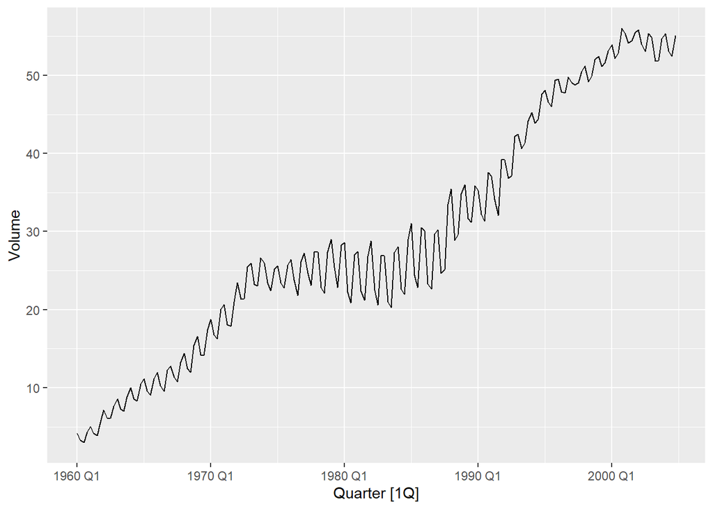

We `sum()` the monthly values for gas production rather than take the `mean()` of the observations of quarterly gas production in `can_gas_q` because we want the *total* amount of gas production within a quarter, not the *average* gas production in a quarter. Taking the mean might also smooth out seasonality that we want to take note of. The quarterly series appears to still be seasonal, peaking in Q1 and Q4 and dropping in Q2 and Q3.

Returning to `retail_ts`, the next code chunk creates a basic plot of `retail_ts` with `autoplot` and a more customized plot.

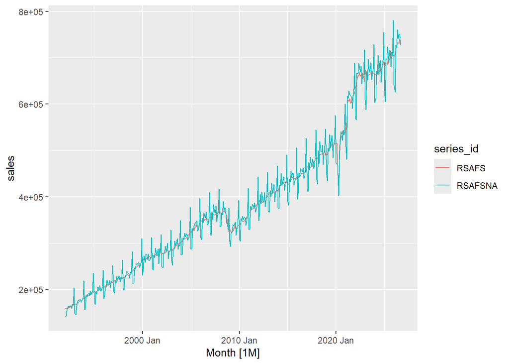

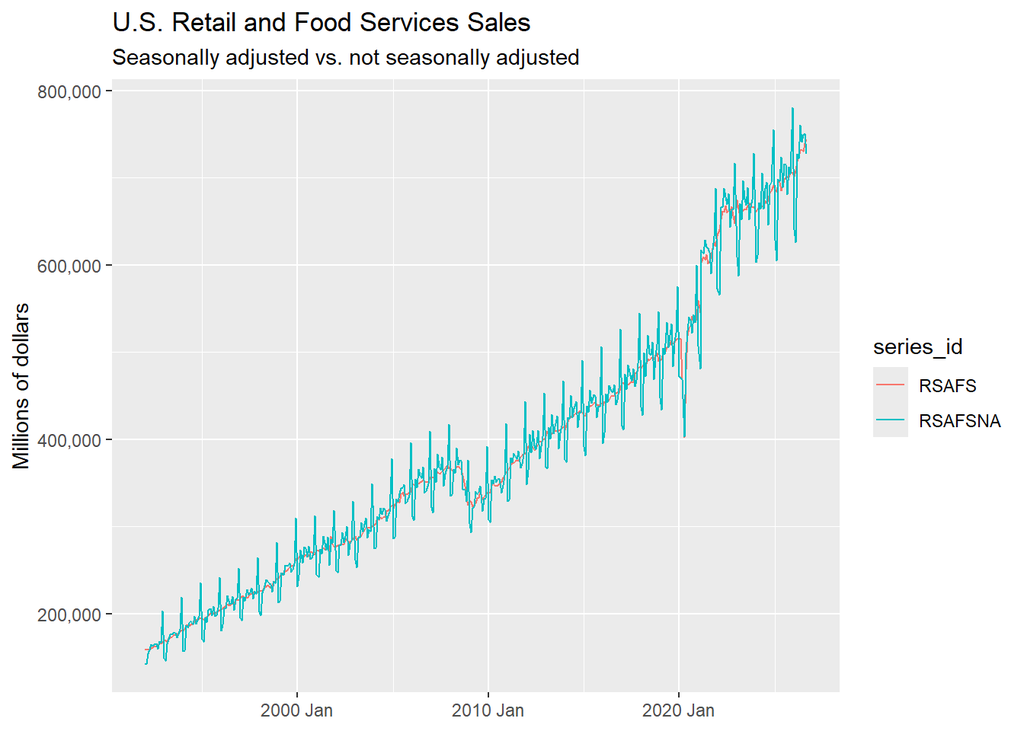

[output not shown]

[output cut: 313 more lines]

[output not shown]

I chose to use scale_y_continuous() to clean up the y-axis of the customized plot of `retail_ts`. Previously, the units of the y-axis were in scientific notation, which is confusing and didn’t quite match the y-axis label of units being in millions of dollars. To match the axis label, the display units on the y-axis needed to match the scale of units in the data set. So, I changed their scale so the data set, y-axis labels, and y-axis units all match up. (However, since it prints this incredibly long string of <theme> customization data, for convenience sake, I won’t be using this method to clean up the y-axis for any other plots, even if they should have it. Please just pretend the y-axis looks like it does here.)

There are consistent spikes and drops in the NSA series, with huge spikes occurring at the end of a year and huge drops occurring at the beginning of a year. The SA series does not have this same pattern. Its levels waver up and down the y-axis, but those small changes don’t seem consistent or to correspond to seasonal changes.

Additionally, the two series do follow the same path in the long run. Both the NSA and SA series are trending up at the same approximate rate over time, and larger peaks and valleys that are caused by recessions or high economic growth are evident in both series.

Below, I’ve also included a customized plot of `can_gas.`

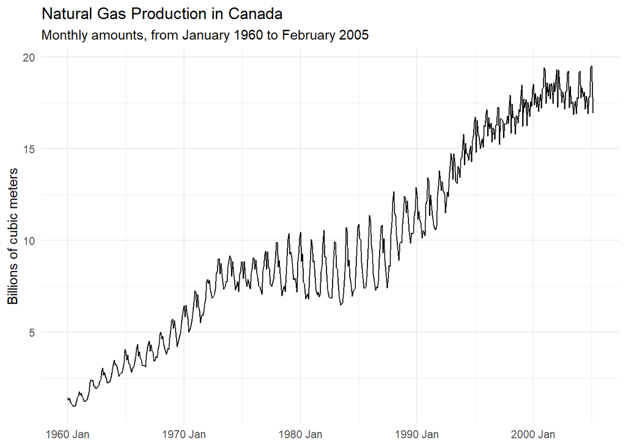

## Transformations

Regarding the above plot of `can_gas`, the seasonal swings do seem to get larger are the series grows, but this is not true over the whole sample. It seems to generally be the case up until around 1990, where the seasonal swings become less pronounced despite the series continuing to trend up over time.

I’m not quite sure how to describe the way the seasonal swings are changing over time, but it isn’t completely related to the series’ level trending up over time. Seasonal swings don’t always get larger as the series grows.

The following code adds a new column to `can_gas` that transforms `Volume` into the natural log of itself, called `log_volume` in the `tsibble`. The logged series is then plotted.

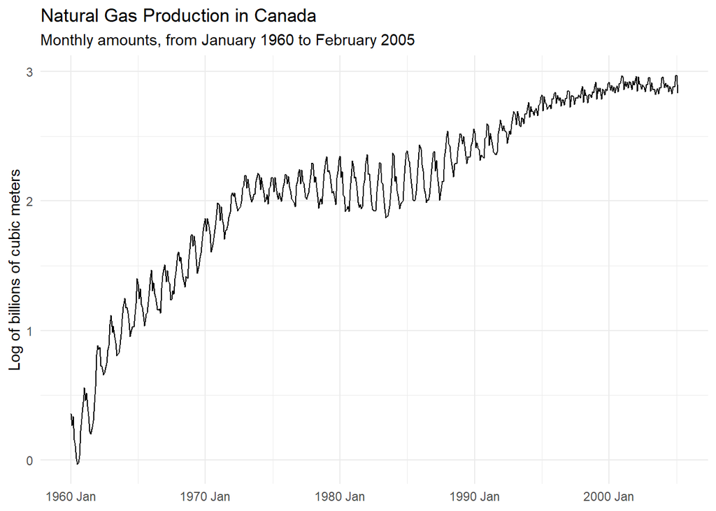

By logging Volume, some of the swings in the series have become less extreme, making me think that some of these swings were seasonal and increased as a result of the series’ level trending upward over time. The trend line of the series also changed, from a positive linear trend to a trend with a shrinking positive rate of change over time.

Since the abnormally large but consistent swings in certain parts of the data did not disappear and become uniform with other swings when Volume was logged, I don’t think it’s worth logging can_gas. While there is likely some seasonality present in the data contributing to the abnormal swings, there is clearly a larger factor at work causing them that is currently unaccounted for. Taking the log of the series doesn’t contribute much to clarity in that department, so I’d say it’s not very useful.

I then repeated the same process of logging and plotting `sales` for the non-seasonally adjusted retail sales data in `retail_ts`, comparing it to a plot of the regular levels of the `sales`.

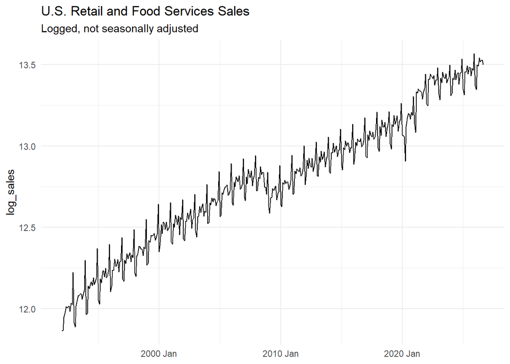

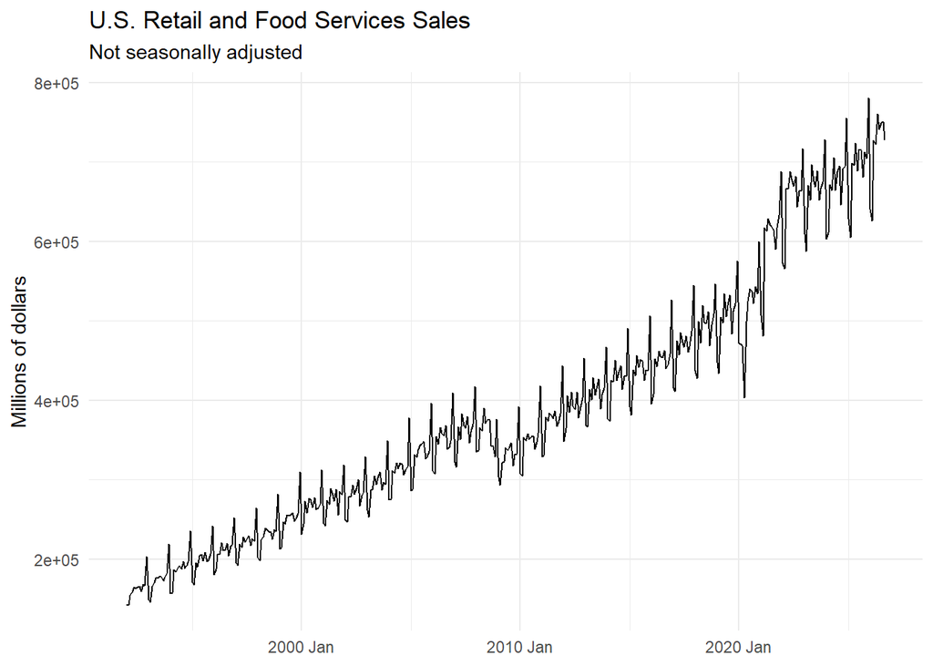

The case for logging `retail_ts` is much stronger than the case for logging `can_gas`. Unlike `can_gas`, by logging the non-seasonally adjusted data in `retail_ts`, the seasonal swings have become mostly consistent in size over time and the trend has become more linear, both of which are the main goals of logging a variable.

This next code chunk adds the month-over-month percentage growth rate to `can_gas` using both the direct/exact method and the first difference of the logged series as an estimation of the growth rate. The directly computed growth rate, `growth_direct`, is plotted. The absolute difference between the direct growth rate and the differenced log growth rate (`growth_logdiff`) is made into the column `growth_gap` and also plotted.

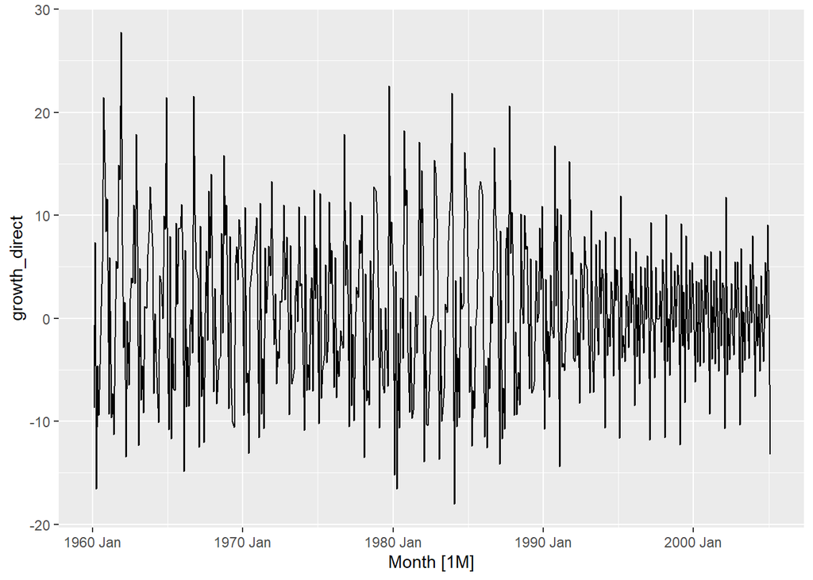

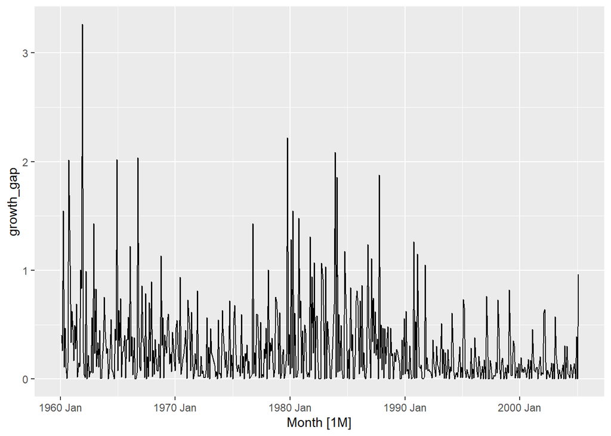

In this case, based on `growth_gap`, I don’t think the log approximation is very good. The growth levels (both positive and negative) that can_gas experiences, particularly in the 1960s and the 1980s, are so extreme that the approximation that the first difference of the logged series provides is just not accurate enough. If the series weren’t as volatile, perhaps the difference of the logged series would be acceptable.

The final code chunk in this section compute the month-over-month log-difference growth rate of each series in `retail_ts`, `RSAFS` and `RSAFNA`, and plots it.

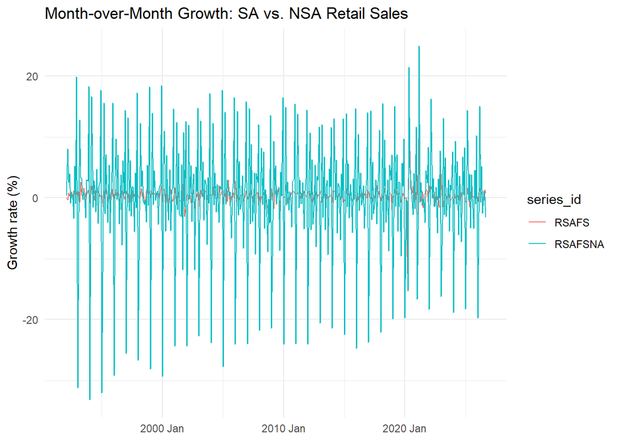

The month-over-month growth rate in the NSA series is much noisier than the month-over-month growth rate of the SA series. As I noted before, the NSA series is definitely affected by seasonality, and this shows in the month-over-month growth rate. When you remove seasonal factors, the growth rate (in this case, the change in retail sales between months) actually doesn’t change that much.

## Seasonality

First, let’s start with a season plots of both `RSAFSNA` and `RSAFS` from `retail_ts`.

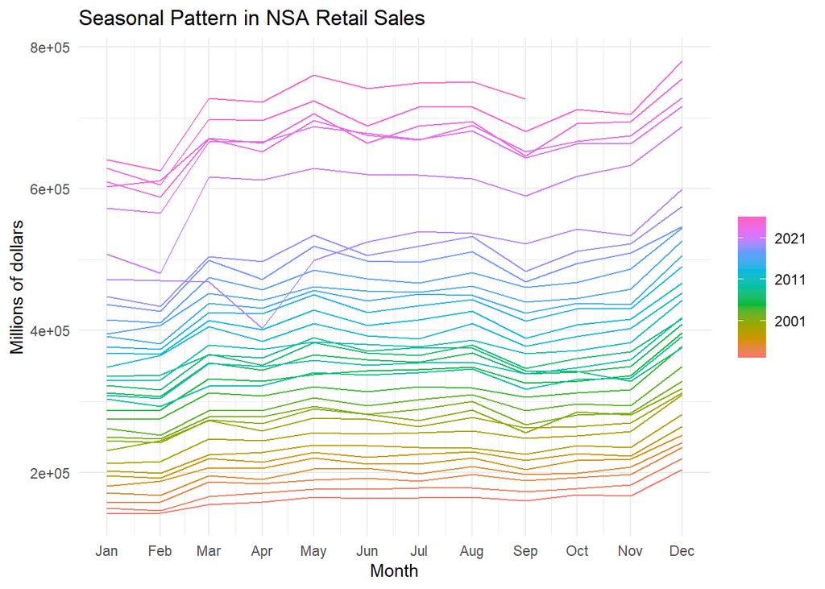

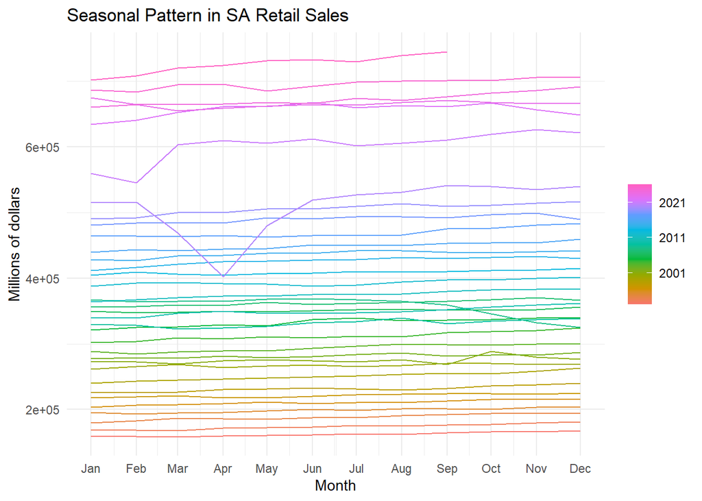

The NSA plot has many more peaks and valleys between months than the SA plot. These peaks and valleys are virtually non-existent in the SA plot, meaning they can be clearly attributed to seasonal effects on retail sales; by removing their effects from the plot, we can more clearly see the steady positive trend of retail sales over time (aside from some outlier, of course, such as the COVID-19 pandemic).

As for the seasonal plot of `can_gas`, let’s try making it with the logged version of `Volume`, `log_volume`.

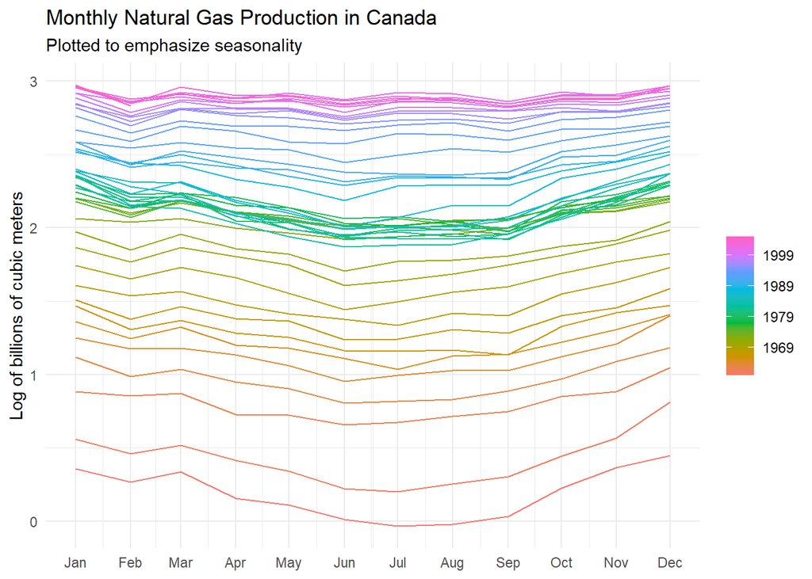

As we enter colder winter months, it appears that natural gas production increases, and throughout the warmer summer months, natural gas production slows down. This makes sense, as one would assume that in a colder country like Canada, more natural gas production in the colder months is necessary to meet the demand of people who want to use the natural gas to heat their homes.

Continuing with `can_gas`, let’s consider using a subseries plot that can help us better see the values of `log_volume` over the years, split by month in order to emphasize the seasonality.

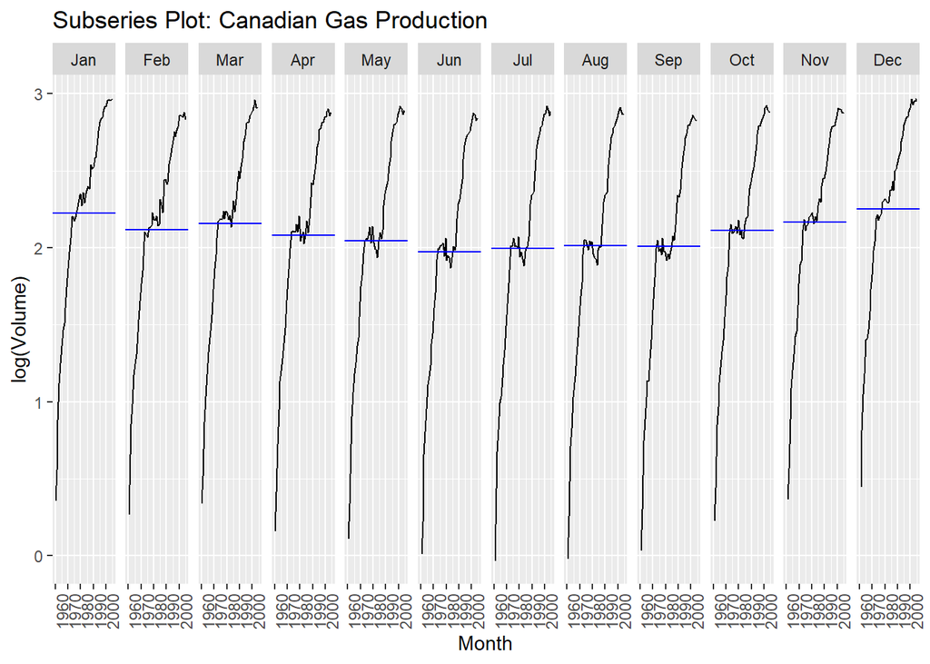

What does it look like if we try to seasonally adjust data ourselves with X-13ARIMA-SEATS?

Below is a plot of the X-13ARIMA-SEATS decomposition of `RSAFSNA` from `retail_ts`.

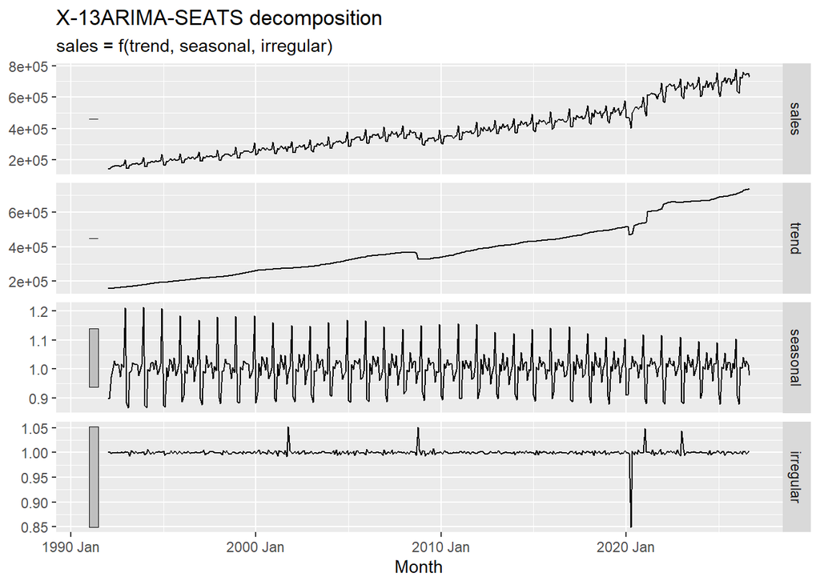

The seasonal factor appears to be the highest in December, with sales ranging from roughly 10-20% higher than the trend (sales start at above 20% higher than the trend at the beginning of the data set, but decrease to about 10% by the most recent years.) The size of the seasonal swings is changing over time, reaching lower positive extremes and roughly consistent negative extremes.

Now, let’s try comparing the self-made seasonally adjusted `RSAFSNA` with the officially seasonally adjusted data released by FRED, `RSAFS`. The difference between the two series has been plotted below by subtracting the log of my seasonal adjustments by the log of the official adjustment, multiplied by 100 to be expressed in percentage terms.

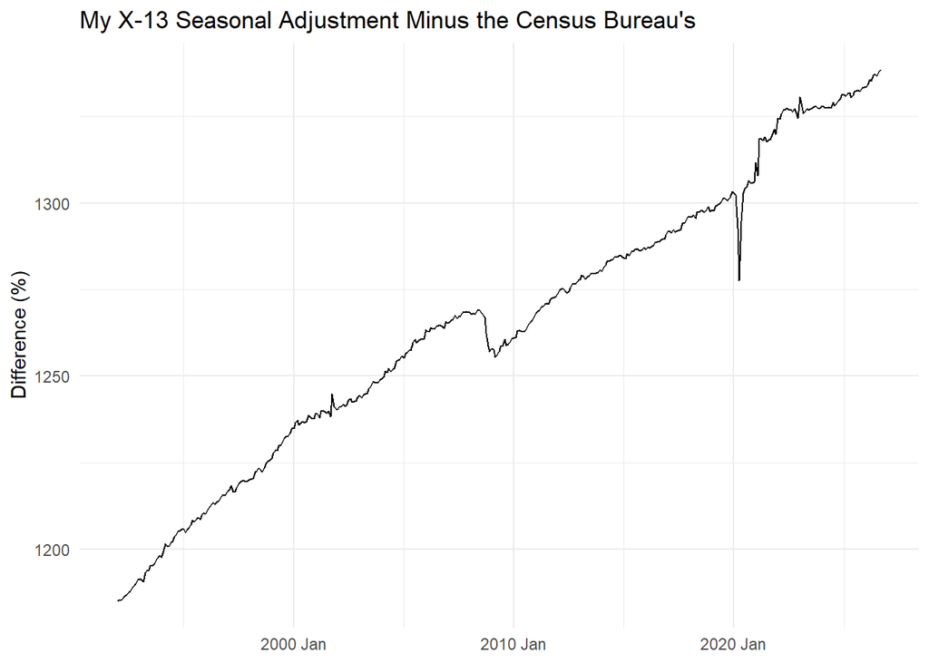

Considering the difference in percent begins in the near 1200% range, I’d say that my adjustment does not match the official one very well. While my adjustment seems to match the official adjustment a little better during major recessions (the difference % drops significantly during both the 2008 financial crisis and the beginning of the COVID-19 pandemic), my seasonal adjustment seems to differ more and more from the census bureau’s as the years in the data set climb higher.

| term | estimate | std.error | statistic | p.value |
| --- | --- | --- | --- | --- |
| (Intercept) | 1.150 | 0.041 | 27.761 | 0.000 |
| trend() | 0.004 | 0.000 | 57.692 | 0.000 |
| season()year2 | -0.112 | 0.052 | -2.144 | 0.032 |
| season()year3 | -0.052 | 0.053 | -0.996 | 0.320 |
| season()year4 | -0.133 | 0.053 | -2.537 | 0.011 |
| season()year5 | -0.174 | 0.053 | -3.305 | 0.001 |
| season()year6 | -0.251 | 0.053 | -4.777 | 0.000 |
| season()year7 | -0.230 | 0.053 | -4.374 | 0.000 |
| season()year8 | -0.219 | 0.053 | -4.170 | 0.000 |
| season()year9 | -0.227 | 0.053 | -4.325 | 0.000 |
| season()year10 | -0.125 | 0.053 | -2.383 | 0.018 |
| season()year11 | -0.078 | 0.053 | -1.480 | 0.140 |
| season()year12 | 0.007 | 0.053 | 0.137 | 0.891 |

The estimated average monthly growth rate of gas production is 0.004. The month with the most significant seasonal effect is June, with a seasonal effect estimate of -0.251.

If we try to plot the fitted values from this model against the `log_volume` data, this is what we end up with:

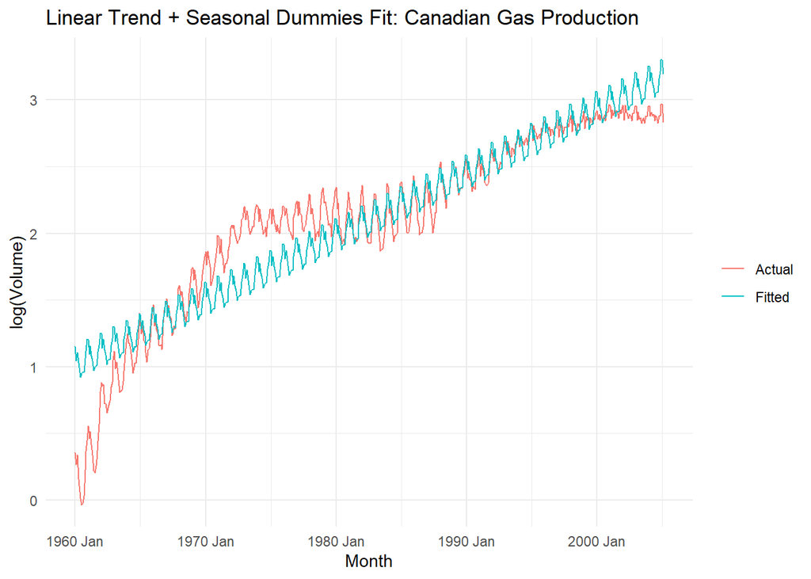

The fitted line does not do a very good job of tracking the actual series, in my opinion. What the fitted line does do is well is track the series between 1990 and 2000, as the series is experiencing some relatively linear growth there. However, even between those years, since the fitted line exhibits constant seasonal variation over the years, it doesn’t capture the reduction in seasonal swings that begin to occur past 1990.

The fitted line does a particularly bad job at capturing the temporary spike in Canadian gas production that begins around 1970, nor does it capture the increased seasonal variation in gas production during that spike.

Overall, due to its nature as a basic linear fitted model and its inability to respond to changes in variations of seasonality over time, the linear trend model struggles to capture some of the important features of the Canadian gas production data.

If our model is well-specified, it should have residuals that look like white noise. When we check this with `gg_tsresiduals`…

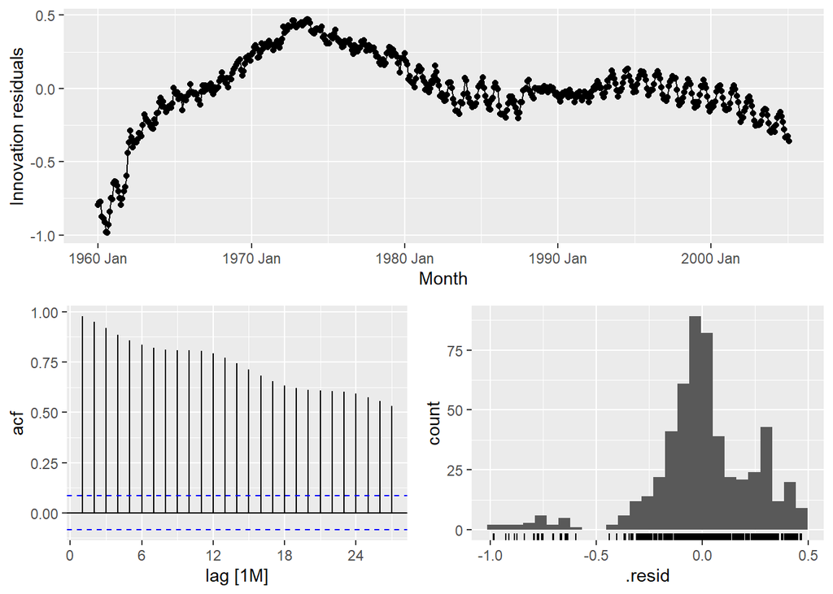

…it doesn’t look too good. But just to be sure, let’s formally test the autocorrelation in the residuals with the Ljung-Box test.

| .model | lb_stat | lb_pvalue |
| --- | --- | --- |
| TSLM(log_volume ~ trend() + season()) | 7774.218 | 0 |

The residuals do not look like white noise. The plot of the ACF clearly shows persistence over time in the residuals, which means there is some factor unaccounted for in the linear trend model that would model the effect of these residuals and take care of them.

At the 5% level, the Ljung-Box text concludes that we reject the null hypothesis that the first 24 lags are uncorrelated.

## Forecast Evaluation

Now, let’s run some tests on the forecast accuracy of a seasonal random walk forecast model and the accuracy of a time series linear model and compare their performance. We’ll do this using the `can_gas` data set, where the seasonal random walk model will be forecasting based on `Volume` and the TSLM model will be forecasting based on the log of `Volume`. We will be running a TS-CV forecast generation method with an expanding window.

| .model | .type | MAE | RMSE |
| --- | --- | --- | --- |
| snaive | Test | 0.562 | 0.702 |
| tslm | Test | 4.009 | 4.362 |

It appears that the SNAIVE model forecasts much more accurately, and both the MAE and RMSE metrics agree on this.

To test if the difference we found above is significant, we’ll conduct a Diebold-Mariano test of equal forecast accuracy.

```
    Diebold-Mariano Test

data:  errs$snaiveerrs$tslm
DM = -31.278, Forecast horizon = 1, Loss function power = 1, p-value <
2.2e-16
alternative hypothesis: two.sided
```

The DM-statistic is -31.278, and the p-value is less than 2.2e-16. With how astronomically small the p-value, it’s clear that we must reject the null hypothesis of the DM test that the SNAIVE model and TSLM model have equal forecast accuracy. In this case, we can see that without a doubt, SNAIVE is more effective at forecasting.

How might each model’s forecast accuracy change when a rolling window is used instead of an expanding window in the TS-CV?

| .model | .type | MAE | RMSE |
| --- | --- | --- | --- |
| snaive | Test | 0.562 | 0.702 |
| tslm | Test | 2.095 | 2.425 |

The MAE of the SNAIVE test is 0.562, and the MAE of the TSLM test is 2.095. The RMSE of the SNAIVE test is 0.702, and the RMSE of the TSLM test is 2.425.

The model whose accuracy changed more with the rolling window was the TSLM model. I imagine this is the case because the TSLM model struggles to make adjust to extreme changes over time in the data, both in its levels and seasonality. By changing the forecast generating method to a rolling window, the TSLM model doesn’t have to take into account old observations that don’t correspond to the current trends of the series. Its ability to respond to changes in how the data series generates is much more enhanced.